# Inferential Analysis: Simulated Exponential Distribution and Hypothesis Testing of Tooth Growth Data

M. Sieviec

8/23/2018

## Overview

This report will discuss in part 1 the mean of a simulated exponential distribution versus the theoretical mean. It will also discuss in part 2 hypothesis testing between two different tooth growth supplements of varying dosage.

## Part 1 — Simulated Exponental Distribution

### Getting Started

With the objective of observing an exponential distribution with parameter $\lambda$ and mean $\frac{1}{\lambda}$, we simulate samples of size n = 40 random exponential variables 1000 times, taking the mean of each complete sample. For our purposes, we have $\lambda$= 0.2, and thus mean = 5. We store these means in the *expmeans* variable. The following code accomplishes this simply, with the first few sample means output:

```r
lambda <- 0.2
expmeans <- NULL
for(i in 1:1000) expmeans <- append(expmeans,mean(rexp(40,lambda)))
head(expmeans)
```

[1] 4.315399 5.796636 6.437335 4.143334 4.352840 4.482991

### Comparison of Means

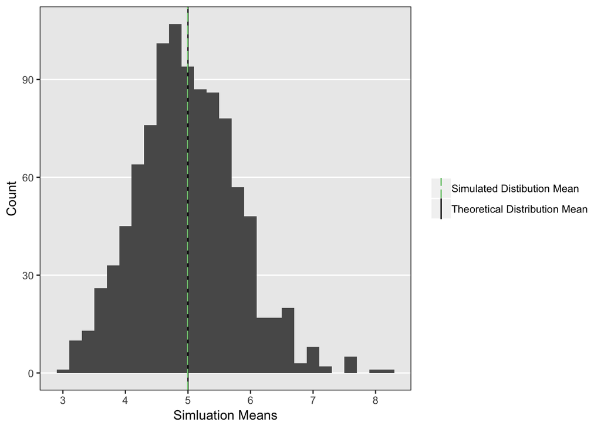

Figure 1-1: Distribution of Means for Simulated Exponential Variables

```r
qplot(expmeans,binwidth=0.2,geom="histogram") +
    geom_vline(aes(xintercept = 1/lambda,color="theoretical"),
               linetype="solid") +
    geom_vline(aes(xintercept = mean(expmeans),color="sample"),
               linetype="longdash") +
    scale_color_manual(values = c(sample = "#7FC97F",theoretical = "black"),
                       labels = c("Simulated Distibution Mean",
                                  "Theoretical Distribution Mean"),
                       guide=guide_legend
                       (override.aes = list(linetype = c("longdash","solid")))) +
    xlab("Simluation Means") + ylab("Count") +
    scale_x_continuous(breaks = 1:8,labels=1:8) +
    theme(panel.grid.major.x = element_blank(),
          panel.grid.minor.x = element_blank(),
          panel.grid.minor.y = element_blank(),
          panel.border = element_rect(color="black",fill=NA),
          legend.title = element_blank())
```

```r
mnames <- c("experimental mean","theoretical mean")
mvals <- c(round(mean(expmeans),3),1/lambda)
mtable <- cbind(mnames,mvals)
colnames(mtable) <- c("Mean Type","Value")
kable(mtable,booktabs=T,caption="Table 1-1: Means of simulated data") %>%
    kable_styling(full_width = F)
```

Table 1-1: Means of simulated data

| Mean Type | Value |
| --- | --- |
| experimental mean | 4.995 |
| theoretical mean | 5 |

We see that, indeed, they are quite similar. Theoretically, our experimental mean would converge to 5 with infinite tests.

### Comparison of Variances

```r
vnames <- c("experimental","theoretical")
vvals <- c(round(var(expmeans),3),(1/lambda)^2/40)
vtable <- cbind(vnames,vvals)
colnames(vtable) <- c("Variance Type","Value")
kable(vtable,booktabs=T,caption="Table 1-2: Variances of simulated data") %>%
    kable_styling(full_width = F)
```

Table 1-2: Variances of simulated data

| Variance Type | Value |
| --- | --- |
| experimental | 0.643 |
| theoretical | 0.625 |

### Analysis of Distribution

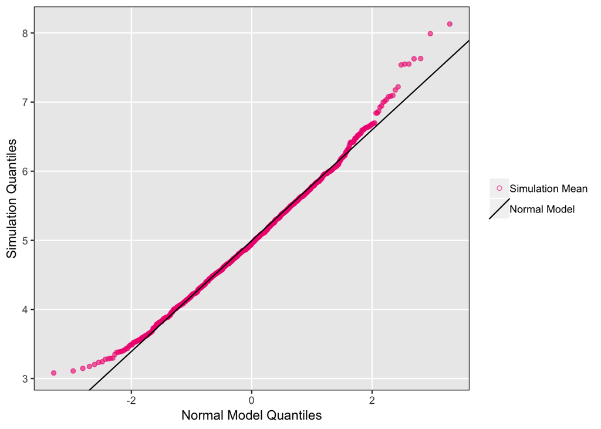

Figure 1-2: Q-Q Plot of Simulated Exponential Data

```r
ggplot(data.frame(expmeans),aes(sample=expmeans,color = "sample")) +
    stat_qq(alpha=0.6) +
    geom_abline(aes(intercept = mean(expmeans),slope = sd(expmeans),
                    color = "model")) +
    xlab("Normal Model Quantiles") +
    ylab("Simulation Quantiles") +
    scale_color_manual(values = c(sample = "#F0027F",
                                  model = "black"),
                       labels = c("Simulation Mean","Normal Model"),
                       guide=guide_legend
                       (override.aes = list(shape = c(1,NA),
                                            linetype = c("blank","solid"),
                                            color = c("#F0027F","black")))) +
    scale_y_continuous(breaks = 1:ceiling(max(expmeans)),
                       labels = 1:ceiling(max(expmeans))) +
    theme(panel.grid.minor.x = element_blank(),
          panel.grid.minor.y = element_blank(),
          panel.border = element_rect(color="black",fill=NA),
          legend.title = element_blank())
```

Based on the Q-Q plot, we see that the distribution for our simulated exponential sample means is roughly normal.

## Part 2 — Hypothesis Testing of Tooth Growth Data

### Getting Started

For this portion, we will work with the *ToothGrowth* dataset, the description of which is as follows:

> The response is the length of odontoblasts (cells responsible for tooth growth) in 60 guinea pigs. Each animal received one of three dose levels of vitamin C (0.5, 1, and 2 mg/day) by one of two delivery methods, orange juice or ascorbic acid (a form of vitamin C and coded as VC).

There are 3 variables in the data: len (growth length), supp (supplement type), and dose (dosage amount).

```r
library(datasets)
data("ToothGrowth")
ToothGrowth %>% group_by(supp, dose) %>%
  summarise(mean(len)) %>%
  kable(booktabs = T, caption = 'Table 2-1: Mean Growth by Supplement and Dose',
        col.names = c('Supplement', 'Dose', 'Mean Growth')) %>%
  kable_styling(full_width = F)
```

Table 2-1: Mean Growth by Supplement and Dose

| Supplement | Dose | Mean Growth |
| --- | --- | --- |
| OJ | 0.5 | 13.23 |
| OJ | 1.0 | 22.70 |
| OJ | 2.0 | 26.06 |
| VC | 0.5 | 7.98 |
| VC | 1.0 | 16.77 |
| VC | 2.0 | 26.14 |

Based on the table, we hypothesize that the orange juice supplement has a higher mean growth overall.

### Hypothesis Testing

```r
ToothGrowth %>% group_by(supp) %>%
  summarise(n()) %>%
  kable(caption = 'Table 2-2: Sample Sizes by Supplement',
        col.names = c('Supplement', 'Samples')) %>%
  kable_styling(full_width = F)
```

Table 2-2: Sample Sizes by Supplement

| Supplement | Samples |
| --- | --- |
| OJ | 30 |
| VC | 30 |

Since n = 30 for both groups, we can start with a t-test of the data with $\alpha$ = 0.05:

```r
ttable <- t.test(ToothGrowth$len[ToothGrowth$supp=="OJ"],
       ToothGrowth$len[ToothGrowth$supp=="VC"])
tablevals <- c(ttable[[1]][1],ttable[[2]][1],ttable[3][1])
testlist <- NULL
for (i in 1:length(tablevals)) {testlist <- c(testlist,tablevals[[i]])}
testlist <- lapply(testlist,round,3)
tablenames <- c(names(ttable[[1]]),names(ttable[[2]]),names(ttable[3]))
testlist <- cbind(tablenames,testlist)
kable(testlist,booktabs=T,digits=3,caption="Table 2-3: T-Test Results",
      col.names=c("Statistic","Value")) %>%
    kable_styling(full_width = F)
```

Table 2-3: T-Test Results

| Statistic | Value |
| --- | --- |
| t | 1.915 |
| df | 55.309 |
| p.value | 0.061 |

We see that the p > 0.05, so we fail to reject the null hypothesis that the supplements have the same mean effect overall. However, we see that there are really 2 distinct groupings–supplement and dose–so we will conduct a two-way ANOVA on the data.

### ANOVA

```r
ToothGrowth$dose <- ToothGrowth$dose %>% factor()
anova.table <- aov(len ~ supp + dose, ToothGrowth) %>%
  summary() %>%
  .[[1]]
anova.table %>% kable(caption = 'Table 2-4: ANOVA of Growth by Supplement and Dose') %>%
  kable_styling(full_width = F)
```

Table 2-4: ANOVA of Growth by Supplement and Dose

|  | Df | Sum Sq | Mean Sq | F value | Pr(>F) |
| --- | --- | --- | --- | --- | --- |
| supp | 1 | 205.350 | 205.35000 | 14.01664 | 0.0004293 |
| dose | 2 | 2426.434 | 1213.21717 | 82.81094 | 0.0000000 |
| Residuals | 56 | 820.425 | 14.65045 | NA | NA |

With see that both supplement and dose are significant at the $\alpha$ = 0.05 level.

### Paired T-Tests

```r
data("ToothGrowth")
ToothGrowth %>% group_by(supp, dose) %>%
  summarise(n()) %>%
  kable(booktabs = T, caption = 'Table 2-5: Sizes of Subsets',
        col.names = c('Supplement', 'Dose', 'Sample size')) %>%
  kable_styling(full_width = F)
```

Table 2-5: Sizes of Subsets

| Supplement | Dose | Sample size |
| --- | --- | --- |
| OJ | 0.5 | 10 |
| OJ | 1.0 | 10 |
| OJ | 2.0 | 10 |
| VC | 0.5 | 10 |
| VC | 1.0 | 10 |
| VC | 2.0 | 10 |

We see that there is an equal number of samples across each subset, so we check QQ plots for normality and boxplots for outliers.

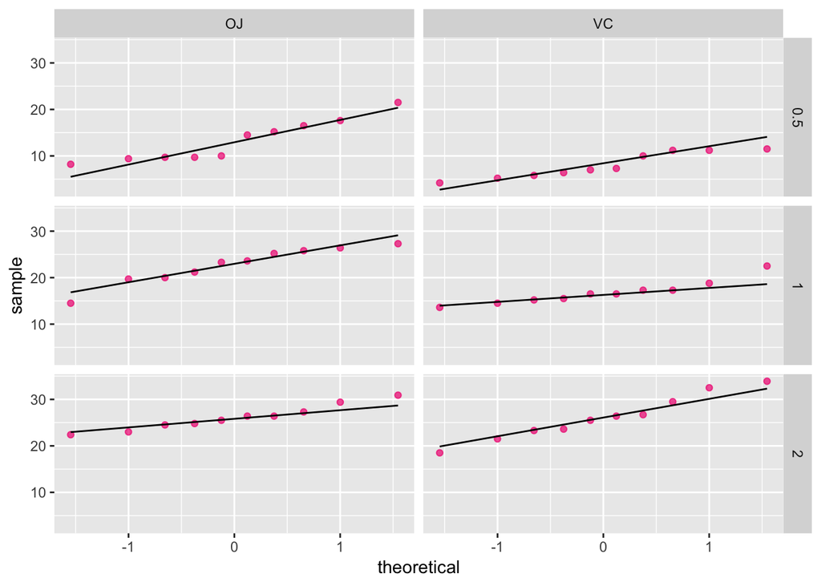

Figure 2-1: Q-Q Plots of Growth Data by Supplement and Dose

```r
ggplot(ToothGrowth, aes(sample = len, color = 'sample')) +
  stat_qq(alpha = 0.7) +
  stat_qq_line(color = "black") +
  scale_color_manual(values = c(sample = "#F0027F")) +
  facet_grid(cols = vars(supp), rows = vars(dose)) +
  theme(legend.position = 'none')
```

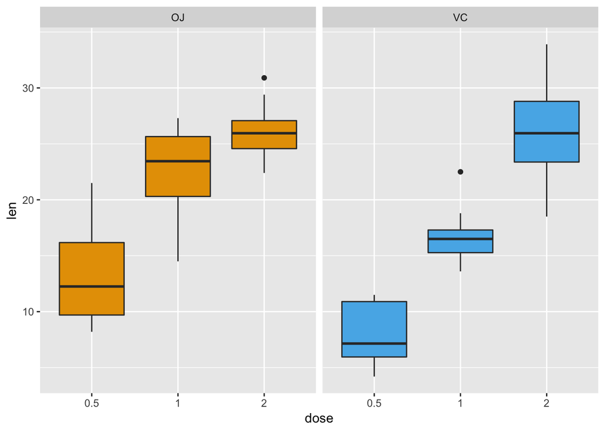

Figure 2-2: Boxplots of Growth Data by Supplement and Dose

```r
ggplot(ToothGrowth, aes(x = factor(dose), y = len)) +
  geom_boxplot(aes(fill = factor(supp))) +
  facet_grid(cols = vars(supp)) +
  xlab("dose") +
  scale_fill_manual(values = c("#E69F00", "#56B4E9")) +
  theme(legend.position = 'none')
```

There are 2 outliers overall, but we will just continue with paired t-tests as the sample sizes are small and roughly normal. We will employ the Bonferroni correction to assess significance.

```r
p1 <- t.test(len ~ supp, ToothGrowth[ToothGrowth$dose == 0.5,], paired = T)$p.value
p2 <- t.test(len ~ supp, ToothGrowth[ToothGrowth$dose == 1,], paired = T)$p.value
p3 <- t.test(len ~ supp, ToothGrowth[ToothGrowth$dose == 2,], paired = T)$p.value

pvals <- c(p1, p2, p3) %>% round(., 3)

table <- bind_cols('P-value' = pvals,
                   'Dose' = unique(ToothGrowth$dose),
                   'p < 0.5/3' = (pvals < 0.5/3))
table %>% kable(booktabs = T, caption = 'Table 2-6: Paired T-Test Results') %>%
  kable_styling(full_width = F)
```

Table 2-6: Paired T-Test Results

| P-value | Dose | p < 0.5/3 |
| --- | --- | --- |
| 0.015 | 0.5 | TRUE |
| 0.008 | 1.0 | TRUE |
| 0.967 | 2.0 | FALSE |

### Conclusion

There is evidence to suggest that the mean tooth growth for the orange juice supplement is higher at both the 0.5mg/day and 1mg/day dosages than for the ascorbic acid supplement. We did not find evidence to suggest a difference at the 2mg/day dosage. Depending on practicality, it may make sense to simply prescribe a 2mg/day dosage of either supplement as that amount granted the highest mean growth for both.

## Notes

This analysis was generated using OSX 10.14.5, RStudio v1.1.463 and the following packages:

- ggplot2 v3.1.0
- kableExtra v1.0.1
- knitr v1.22